# LH Final Project BIOS:611

12-14-2023

#Understanding the Data: The North Carolina State Center for Health Statistics (NCSHS) within the North Carolina Department of Health and Human Services collects and reports a multitude of data on topics such as cancer, minority health,and birth defects. NCSHS is also partnered with states nationwide to provide surveillance data which includes the Behavioral Risk Factor Surveillance System (BRFSS), Child Health Assessment Monitoring Program (CHAMP), and Pregnancy Risk Assessment Monitoring System (PRAMS).

#Scope of this Report: Annually, as a part of vital statistics reports, NCSHS also reports mortality data that dates back to 1968. Here we will be analyzing mortality data from 2021 which includes the following variables:

- Place of Death
- County of Occurrence
- City of Occurrence
- Decedent’s Residence County
- Decedent’s Residence City
- Sex
- Race of Decedent
- Age at Death
- Decedent’s Education
- Place of Injury (if injury death)
- Veteran Status
- Death Month
- Death Date
- Death Year

## Plot 1:

The first plot looks at the total counts of mortality in NC in 2021 stratified by sex.

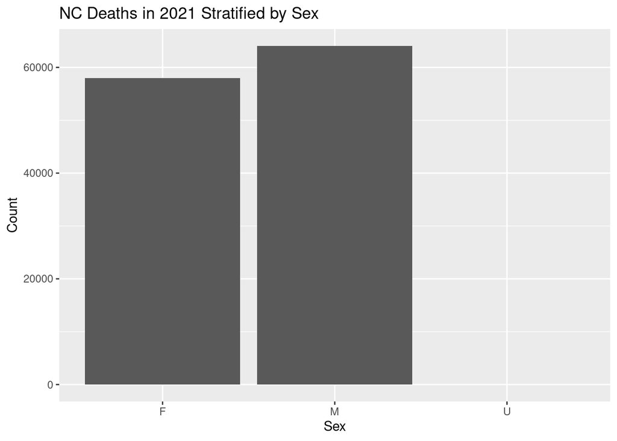

```r
#Deaths by Sex
p = ggplot(NC_VS_2021, aes(x=SEX)) +
  geom_histogram(stat="count") +
  labs(x = "Sex", y = 'Count') +
  theme(axis.text.x = element_text()) +
  ggtitle("NC Deaths in 2021 Stratified by Sex");
p
```

## Plot 2:

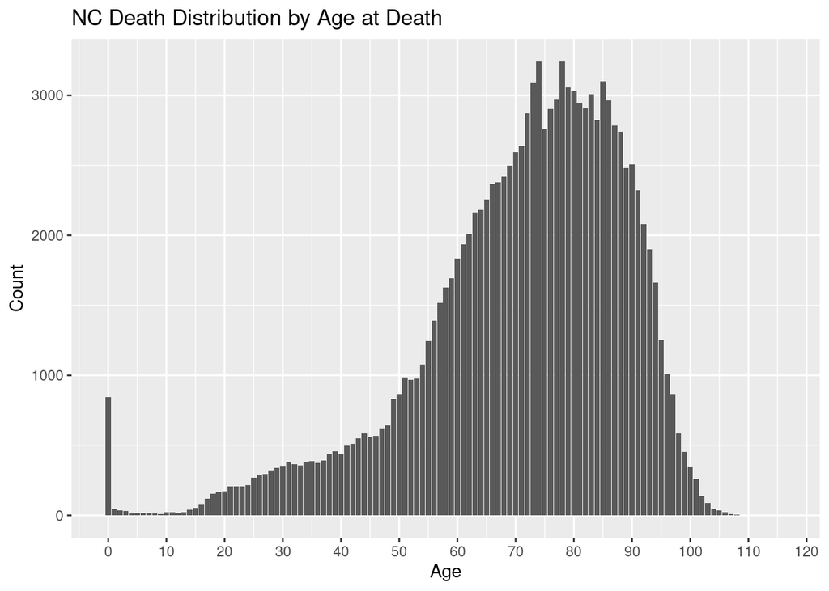

```r
#Death by Age
p <- ggplot(NC_VS_2021, aes(x = AGEYRS)) +
  geom_histogram(stat = "count", binwidth = 10) +
  labs(x = "Age", y = 'Count') +
  scale_x_continuous(breaks = seq(0, max(NC_VS_2021$AGEYRS) + 10, 10)) +
  theme(axis.text.x = element_text()) +
  ggtitle("NC Death Distribution by Age at Death")
print(p)
```

## Plot 3:

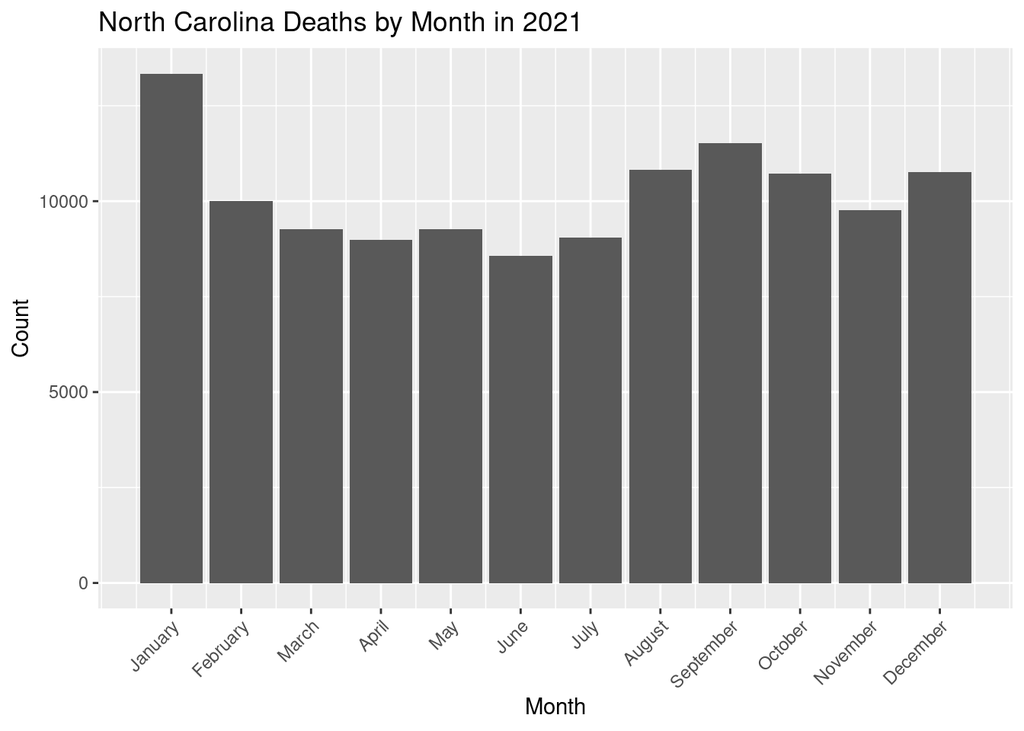

```r
#Death by Month
months_labels <- c("January", "February", "March", "April", "May", "June", "July", "August", "September", "October", "November", "December")

p <- ggplot(NC_VS_2021, aes(x = DHTMO)) +
  geom_histogram(stat = "count") +
  labs(x = "Month", y = 'Count') +
  scale_x_continuous(breaks = 1:12, labels = months_labels) +
  theme(axis.text.x = element_text(angle = 45, hjust = 1)) +
  ggtitle("North Carolina Deaths by Month in 2021")
print(p)
```

## Plot 4:

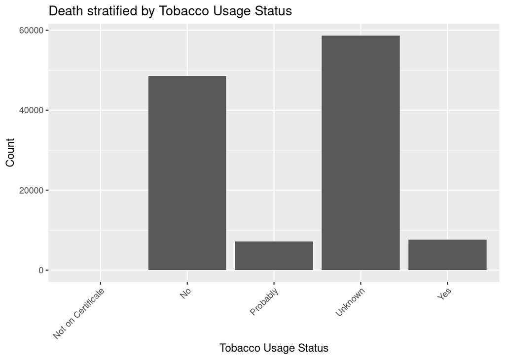

```r
#Death Stratified by Tobacco Usage
code_labels <- c("C" = "Not on Certificate", "N" = "No", "P" = "Probably", "U" = "Unknown", "Y" = "Yes")

p <- ggplot(NC_VS_2021, aes(x = TOBACCO)) +
  geom_histogram(stat = "count") +
  labs(x = "Tobacco Usage Status", y = 'Count') +
  scale_x_discrete(labels = code_labels) +
  theme(axis.text.x = element_text(angle = 45, hjust = 1)) +
  ggtitle("Death stratified by Tobacco Usage Status")
print(p)
```

##Plot 5:

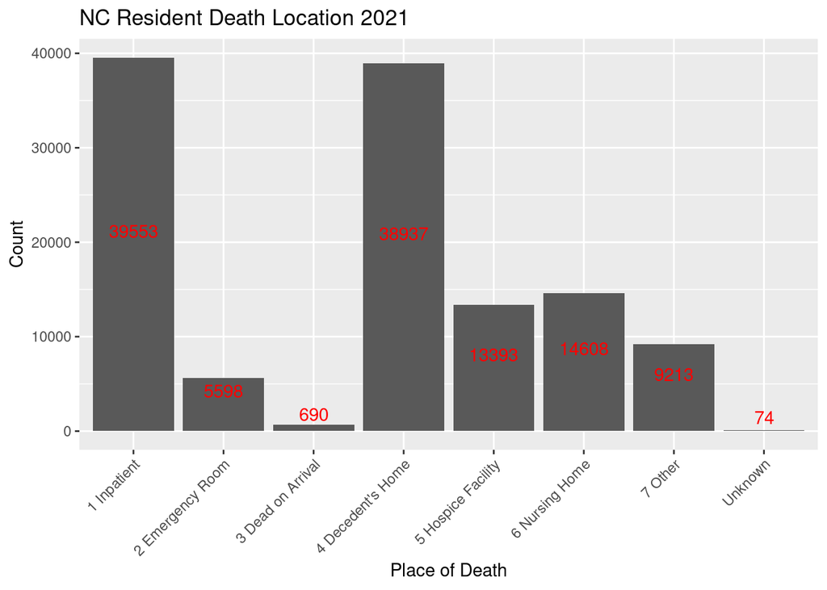

```r
#Place of Death Distribution
custom_labels <- c("1 Inpatient", "2 Emergency Room", "3 Dead on Arrival",
                   "4 Decedent's Home", "5 Hospice Facility", "6 Nursing Home", "7 Other",
                   "Unknown")

p <- ggplot(NC_VS_2021, aes(x = factor(DPLACE))) +
  geom_histogram(stat = "count") +
  labs(x = "Place of Death", y = 'Count') +
  scale_x_discrete(labels = custom_labels) +
  theme(axis.text.x = element_text(angle = 45, hjust = 1)) +
  ggtitle("NC Resident Death Location 2021") +
  geom_text(stat = "count", aes(label = after_stat(count), vjust = -0.5), color = "red", position = position_stack(vjust = 0.5))
print(p)
```

##Additional Analysis:

```r
freq_table <- table(NC_VS_2021$COD1)
max_frequency <- max(freq_table)
most_common_values <- names(freq_table[freq_table == max_frequency])
cat("Most common frequency:", max_frequency, "\n")
```

```
## Most common frequency: 14228
```

```r
cat("Most common value(s):", most_common_values, "\n")
```

```
## Most common value(s): U071
```

```r
freq_table <- table(NC_VS_2021$COD2)
max_frequency <- max(freq_table)
most_common_values <- names(freq_table[freq_table == max_frequency])
cat("Most common frequency:", max_frequency, "\n")
```

```
## Most common frequency: 9459
```

```r
cat("Most common value(s):", most_common_values, "\n")
```

```
## Most common value(s): F179
```

```r
freq_table <- table(NC_VS_2021$COD3)
max_frequency <- max(freq_table)
most_common_values <- names(freq_table[freq_table == max_frequency])
cat("Most common frequency:", max_frequency, "\n")
```

```
## Most common frequency: 5069
```

```r
cat("Most common value(s):", most_common_values, "\n")
```

```
## Most common value(s): I10
```

Mortality report data contains up to 20 different mentioned causes of death in order that utilize ICD-10 codes. The frequencies projected show the most common ICD-10 codes for preliminary, secondary, and tertiary cause of death.

1. Most common preliminary cause of death = U071 (COVID-19) 14,228
2. Most common secondary cause of death = F179 (Nicotine Dependence, Unspecified, with Withdrawal) 9,459
3. Most common tertiary cause of death = I10 (Essential Hypertension and Hypertensive Renal Disease) 5,069

## Future Questions

These preliminary findings help understand the shape and distribution of the data but additional analyses such as regressions could be done to better map associations. It would also be interesting to run the same plots on NC vital statistics mortality data from previous years prior to COVID-19 to see how the plots looking at counts of death by age, sex, distribution throughout the year, death place, etc differed possibly as a result of COVID-19 and overall to see the changes in death distributions across these topics. This insight could help identify areas of public health need.